# Práctica_IIP

2024-05-18

Trabaje con el archivo de datos “better_life.xls”. Este archivo contiene los indicadores simples que componen el índice de “Better Life” calculado por la OCDE.

- Vivienda
  - Vivienda sin lo básico
  - Gastos de vivienda
  - Cuartos por persona
- Ingreso
  - Ingreso neto del hogar ajustado
  - Riqueza del hogar neta
- Trabajo
  - Inseguridad laboral
  - Tasa de empleo
  - Desempleo a largo plazo
  - Ganancias personales
- Comunidad
  - Calidad en las redes de apoyo
- Educación
  - Asistencia escolar
  - Habilidades estudiantiles
  - Años de educación
- Ambiente
  - Contaminación del aire
  - Calidad del agua
- Compromiso civico
  - Compromiso civico
  - Intensión de voto
- Salud
  - Esperanza de vida al nacer
  - Salud auto-percepción
- Satisfacción con la vida
  - Satisfacción con la vida
- Seguridad
  - Se siente seguro al caminar solo por la calle
  - Tasa de homicidio
- Balance trabajo-vida
  - Trabajadores con largas jornadas
  - Tiempo dedicado al ocio

```r
librerias <- c("ggplot2", "dplyr", "tidyr", "readr", "VIM", "tidyverse", "openxlsx", "factoextra", "hopkins", "mice", "ggthemes", "scales","readxl")

invisible(lapply(librerias, library, character.only = TRUE))
```

```
## VIM is ready to use.
```

```
## Suggestions and bug-reports can be submitted at: https://github.com/statistikat/VIM/issues
```

```r
setwd("C:/Users/Docente/OneDrive - Universidad de Costa Rica/IC2024/Indicadores_IC2024/Evaluaciones IC2024/Script_II_Parcial")

better_life <- read_excel("better_life.xls")
```

1.1 Con este archivo revíse gráficamente los valores faltantes.

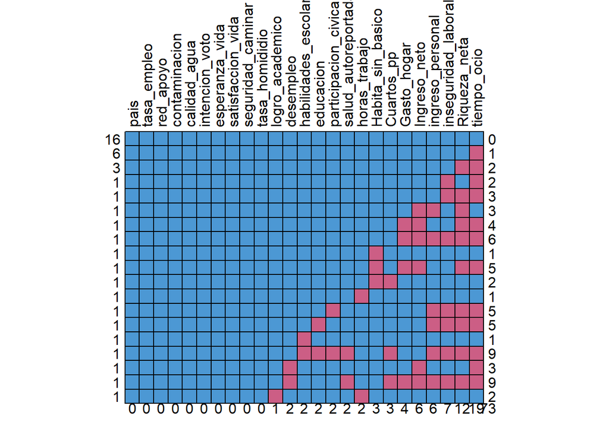

```
##    pais tasa_empleo red_apoyo contaminacion calidad_agua intencion_voto
## 16    1           1         1             1            1              1
## 6     1           1         1             1            1              1
## 3     1           1         1             1            1              1
## 1     1           1         1             1            1              1
## 1     1           1         1             1            1              1
## 1     1           1         1             1            1              1
## 1     1           1         1             1            1              1
## 1     1           1         1             1            1              1
## 1     1           1         1             1            1              1
## 1     1           1         1             1            1              1
## 1     1           1         1             1            1              1
## 1     1           1         1             1            1              1
## 1     1           1         1             1            1              1
## 1     1           1         1             1            1              1
```

[output cut: 111 more lines]

```r
md.pattern(better_life, rotate.names = T)
```

1.2. Cuántos valores faltantes hay en total?

Respuesta: 73

1.3. Cuál es la variable con más valores faltantes?

Respuesta: tiempo ocio

1.4. En este escenario (en estas variables que construyen el índice “better life”), porqué hay valores faltantes?

Respuesta: porque los países no reportan o no construyen esos indicadores simples.

4.1. Impute con knn o con regresión la variable que tiene más missing values.

```r
better_life_knn<-kNN(better_life[,-1],variable = c("tiempo_ocio"),k=4)
```

¿Cómo sería con regresión?

```r
datos_completos<- better_life %>% filter(!is.na("tiempo_ocio"))


#usemos como predictores solo las variables que no tienen NA
mod <- lm(datos_completos$tiempo_ocio ~ datos_completos$tasa_empleo+datos_completos$red_apoyo+datos_completos$contaminacion+datos_completos$calidad_agua+datos_completos$intencion_voto+datos_completos$esperanza_vida+datos_completos$satisfaccion_vida+datos_completos$seguridad_caminar+ datos_completos$tasa_homididio)


step(mod) #selección con AIC
```

```
## Start:  AIC=-14.06
## datos_completos$tiempo_ocio ~ datos_completos$tasa_empleo + datos_completos$red_apoyo +
##     datos_completos$contaminacion + datos_completos$calidad_agua +
##     datos_completos$intencion_voto + datos_completos$esperanza_vida +
##     datos_completos$satisfaccion_vida + datos_completos$seguridad_caminar +
##     datos_completos$tasa_homididio
##
##                                     Df Sum of Sq    RSS     AIC
## - datos_completos$esperanza_vida     1   0.00039 4.6793 -16.054
## - datos_completos$contaminacion      1   0.02233 4.7012 -15.951
## - datos_completos$red_apoyo          1   0.02559 4.7045 -15.936
## - datos_completos$tasa_empleo        1   0.07748 4.7564 -15.694
## - datos_completos$tasa_homididio     1   0.12618 4.8051 -15.470
## - datos_completos$intencion_voto     1   0.21951 4.8984 -15.047
## <none>                                           4.6789 -14.056
## - datos_completos$seguridad_caminar  1   0.51817 5.1971 -13.745
## - datos_completos$calidad_agua       1   0.57187 5.2508 -13.519
## - datos_completos$satisfaccion_vida  1   0.72131 5.4002 -12.901
##
## Step:  AIC=-16.05
## datos_completos$tiempo_ocio ~ datos_completos$tasa_empleo + datos_completos$red_apoyo +
##     datos_completos$contaminacion + datos_completos$calidad_agua +
##     datos_completos$intencion_voto + datos_completos$satisfaccion_vida +
##     datos_completos$seguridad_caminar + datos_completos$tasa_homididio
##
##                                     Df Sum of Sq    RSS     AIC
## - datos_completos$contaminacion      1   0.02303 4.7023 -17.946
## - datos_completos$red_apoyo          1   0.03136 4.7106 -17.907
## - datos_completos$tasa_empleo        1   0.08159 4.7609 -17.673
## - datos_completos$tasa_homididio     1   0.18199 4.8613 -17.214
## - datos_completos$intencion_voto     1   0.22144 4.9007 -17.037
## <none>                                           4.6793 -16.054
## - datos_completos$seguridad_caminar  1   0.53041 5.2097 -15.691
## - datos_completos$calidad_agua       1   0.57163 5.2509 -15.518
## - datos_completos$satisfaccion_vida  1   0.77513 5.4544 -14.682
##
## Step:  AIC=-17.95
## datos_completos$tiempo_ocio ~ datos_completos$tasa_empleo + datos_completos$red_apoyo +
##     datos_completos$calidad_agua + datos_completos$intencion_voto +
##     datos_completos$satisfaccion_vida + datos_completos$seguridad_caminar +
```

[output cut: 35 more lines]

```
## - datos_completos$seguridad_caminar  1   0.94265 5.7345 -19.580
## - datos_completos$satisfaccion_vida  1   1.40380 6.1957 -17.878
## - datos_completos$calidad_agua       1   2.06440 6.8563 -15.649
##
## Step:  AIC=-22.91
## datos_completos$tiempo_ocio ~ datos_completos$calidad_agua +
##     datos_completos$intencion_voto + datos_completos$satisfaccion_vida +
##     datos_completos$seguridad_caminar
##
##                                     Df Sum of Sq    RSS     AIC
## <none>                                           4.9280 -22.914
## - datos_completos$intencion_voto     1   0.75456 5.6826 -21.780
## - datos_completos$seguridad_caminar  1   1.11396 6.0420 -20.431
## - datos_completos$satisfaccion_vida  1   1.37076 6.2988 -19.515
## - datos_completos$calidad_agua       1   2.21713 7.1451 -16.741
```

```
##
## Call:
## lm(formula = datos_completos$tiempo_ocio ~ datos_completos$calidad_agua +
##     datos_completos$intencion_voto + datos_completos$satisfaccion_vida +
##     datos_completos$seguridad_caminar)
##
## Coefficients:
##                       (Intercept)       datos_completos$calidad_agua
##                          12.35437                           -0.07434
##    datos_completos$intencion_voto  datos_completos$satisfaccion_vida
##                           0.02310                            0.63438
## datos_completos$seguridad_caminar
##                           0.03997
```

```r
mod <- lm(datos_completos$tiempo_ocio ~ datos_completos$calidad_agua+datos_completos$intencion_voto+datos_completos$satisfaccion_vida+datos_completos$seguridad_caminar)


#Programamos una funcion para estimar los valores
pred1  <- function(x){
  resp <-  mod$coefficients[1] +  mod$coefficients[2]*x[, 1] +  mod$coefficients[3]*x[, 2]+ mod$coefficients[4]*x[, 3]+ mod$coefficients[5]*x[, 4]
  return(resp)
  }

faltantes<-which(is.na(better_life$tiempo_ocio))


#Se hace la estimacion
better_life[faltantes,"tiempo_ocio"] <- pred1(better_life[faltantes,c("calidad_agua","intencion_voto","satisfaccion_vida","seguridad_caminar")])
```

4.2. Explique: porqué escogió este método y no el otro?

Respuesta: para regresión hay que poner más cuidado en el cumplimiento de supuestos. Revisar R2 etc.

5. Haga una imputación múltiple con en el resto de la base, es decir, la base después de haber imputado con knn la variable con más missings. Utilice como semilla el número 53

```r
better_life_imp = mice(better_life_knn[,-c(25)], m = 10, seed = 53) #opcional met=
better_life_imp_base<-complete(better_life_imp)
```

6. Normalice toda la base utilizando z-scores

```r
base.zscore <-  as.data.frame(scale(better_life_imp_base, center = TRUE, scale = TRUE))
```

7. Construya el índice utilizando un promedio ponderado. Hágala la ponderación con base en criterio de expertos. Para esto asuma que dos expertos dieron su opinión de cómo debía ponderarse estos indicadores. El primer experto asigna una ponderación equitativa a todos los indicadores, pero el segundo experto asigna una ponderación más fuerte (de 10%) a la dimensión “balance trabajo-vida”.

```r
expertos <- function(pesos_expertos) {

  pesos_promedio <- colMeans(pesos_expertos)
  return(pesos_promedio)

}

c1<-c(rep(0.04166667,24))
c2<-c(rep(0.04090909,22),0.05, 0.05)

experto = expertos(pesos_expertos=rbind(c1, c2))


mediapond = function(base, pesos) {
  if (ncol(base) != length(pesos)) {
    stop("El número de columnas en los datos no coincide con la longitud del vector de pesos.")
  }
    media_ponderada = rowSums(base * pesos)
    base = cbind(base, media_ponderada)
    return(base)
}
```

```r
indice<-mediapond(base.zscore, experto)
```

```r
summary(indice$media_ponderada)
```

```
##      Min.   1st Qu.    Median      Mean   3rd Qu.      Max.
## -0.578732 -0.268214  0.066881 -0.001088  0.277298  0.458453
```

```r
agregacion <- function(data, weights, method) {
  # Verificar que la longitud de las columnas de la base de datos y los pesos coincida
  if (ncol(data) != length(weights)) {
    stop("La longitud de las columnas de la base de datos y los pesos debe ser la misma.")
  }

  # Vector para almacenar los indicadores compuestos
  indCom <- numeric(nrow(data))

  # Calcular el indicador compuesto para cada fila de la base de datos
  for (i in 1:nrow(data)) {
    row <- as.numeric(data[i, ])
    if (method == "lineal") {
      indCom[i] <- sum(row * weights)
    } else if (method == "geometrico") {
      indCom[i] <- prod(row^weights)^(1/sum(weights))
    } else {
      stop("Método de agregación no válido. Por favor, elija 'lineal' o 'geometrico'.")
    }
  }

  return(indCom)
}
base2<-agregacion(base.zscore, experto, "lineal")
summary(base2)
```

```
##     Min.  1st Qu.   Median     Mean  3rd Qu.     Max.
## -0.57425 -0.27061  0.06106  0.00000  0.28156  0.45583
```

```r
base3<-cbind(better_life[,1],base2)
View(base3)
```

8. Cuáles son los tres países con mejor puntuación del “Better life index” que obtuvo?

Respuesta:

Nueva Zelanda, Australia, EEUU.